# COMPSCIX 415.2 Homework 6

Michelle Gomez

7/17/2018

# Exercise 1

1. What variables are in this data set?  
   There are 2 categorical variables (outcome, smoker) and one quantitative variable (age).

```r
glimpse(Whickham)
```

```
## Observations: 1,314
## Variables: 3
## $ outcome <fct> Alive, Alive, Dead, Alive, Alive, Alive, Alive, Dead, ...
## $ smoker  <fct> Yes, Yes, Yes, No, No, Yes, Yes, No, No, No, No, Yes, ...
## $ age     <int> 23, 18, 71, 67, 64, 38, 45, 76, 28, 27, 28, 34, 20, 72...
```

2. How many observations are there and what does each represent?  
   There are 1,314 observations/rows and each represents a different subject.
3. Create a table (use the R code below as a guide) and a visualization of the relationship between smoking status and outcome, ignoring age. What do you see? Does it make sense?

```r
library(mosaicData)
library(tidyverse)
Whickham2 <-Whickham %>% count(smoker, outcome) %>%
  arrange_all() %>% mutate(n/1314)
Whickham2
```

```
## # A tibble: 4 x 4
##   smoker outcome     n `n/1314`
##   <fct>  <fct>   <int>    <dbl>
## 1 No     Alive     502    0.382
## 2 No     Dead      230    0.175
## 3 Yes    Alive     443    0.337
## 4 Yes    Dead      139    0.106
```

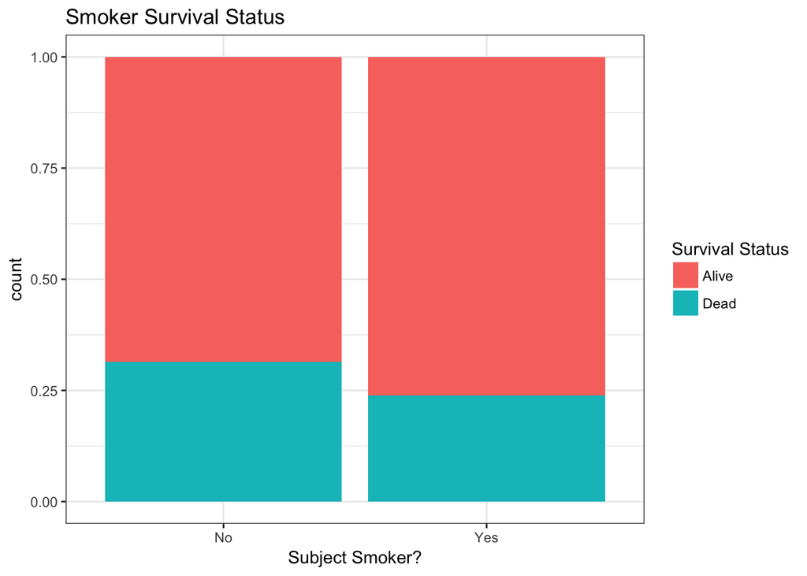

```r
Whickham2 %>%
ggplot() + geom_bar(aes(x = smoker, y = n, fill = outcome), stat = 'identity', position = 'fill') + labs(x = 'Subject Smoker?', y = 'count' , fill = 'Survival Status', title = 'Smoker Survival Status') +
theme_bw()
```

The table makes sense but the visualization could be better. I think the issue is that there are more non-smoker subjects so this sample may not be a true representation of the population.

4. Recode the age variable into an ordered factor with three categories: age <= 44, age > 44 & age <= 64, and age > 64. Now, recreate visualization from above, but facet on your new age factor. What do you see? Does it make sense?  
   I see 3 facets by age group, segmented my smoker status, and filled in by survival outcome. Overall, it makes sense that the older you are the less likely you are to survive, and also that if you smoke you are more likeley to die (though it doesn’t seem statisticaly significant).

```r
library(mosaicData)
library(dplyr)
x <- Whickham$age
cate_age <- case_when(x <= 44 ~ 'age <= 44',
                      x > 44 &  x <= 64 ~ '44 > age <= 64',
                      x > 64 ~ 'age > 64')
age_fct <- factor(cate_age, ordered = TRUE)

age_fct <- fct_relevel(age_fct, 'age <= 44', '44 > age <= 64', 'age > 64')
levels(age_fct)
```

```
## [1] "age <= 44"      "44 > age <= 64" "age > 64"
```

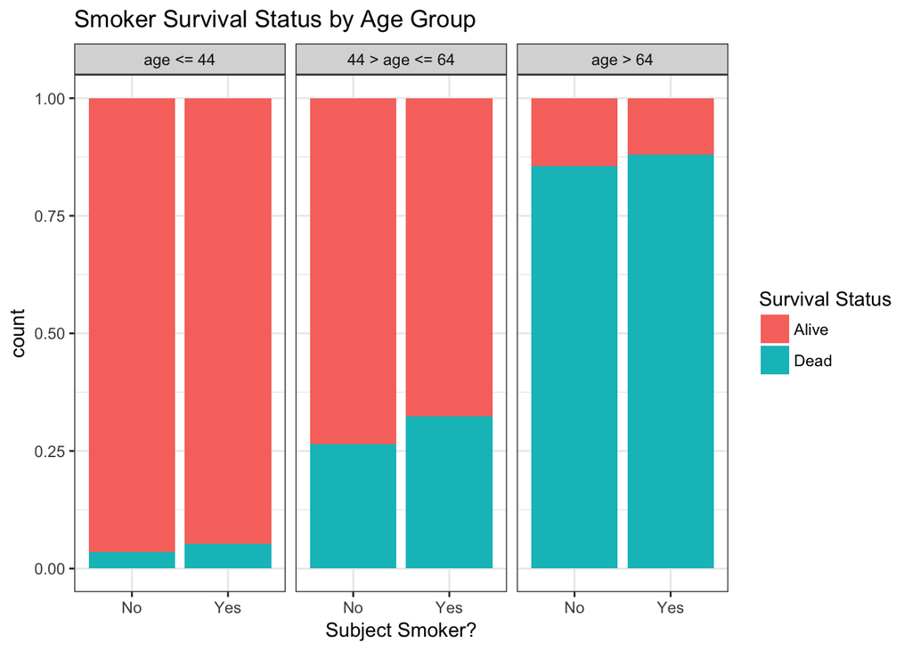

```r
Whickham3 <- Whickham %>% mutate(age_fct) %>% count(smoker, outcome, age_fct) %>%
  arrange_all()

Whickham3 %>%
ggplot() + geom_bar(aes(x = smoker, y = n, fill = outcome), stat = 'identity', position = 'fill') +
  facet_grid(~ age_fct) +
  labs(x = 'Subject Smoker?', y = 'count' , fill = 'Survival Status', title = 'Smoker Survival Status by Age Group') +
theme_bw()
```

# Exercise 2